# ISA 616 Project 2

Author

Samantha Erne and Amber Kopitke

Published

October 12, 2023

# Project Overview

In this project, we will be using data collected from 2019-2021 to visualize geographic trends of Farmer School of Business graduates. The client for this project is Mr. Kirk Bogard of the FSB External Relations office.

The Business Value Proposition that we created for this project is pictured below. In this BVP, we described our client, their jobs, and how our solution will both kill their pains as well as provide additional gains to the clients. We plan to create a dashboard to visualize historical geographic trends to help our client better perform his job and create better student outcomes.

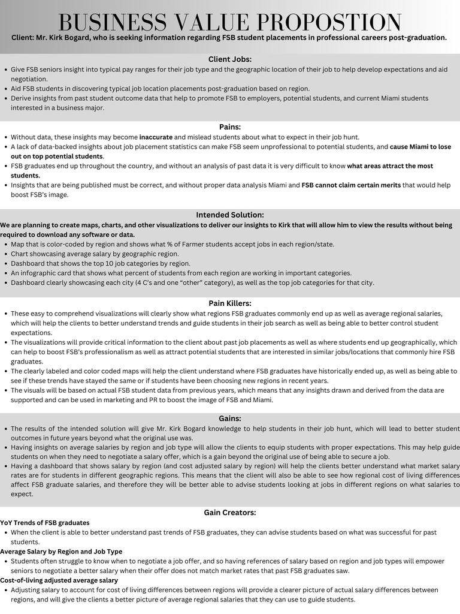

## Data Description

The data that we will be using for this project is data collected from graduating FSB students in the classes of 2019, 2020, and 2021. This data includes information on major, job title, company, job location, salary, and much more. Analyzing this data will allow us to provide our client with critical insights regarding the geographic trends of FSB graduates that will help them to prepare seniors for the job search and better place students in jobs.

Below is a snapshot of the data set before any cleaning has been done.

```r
fsb_data= readRDS("FSB_BI_Survey_2019_2021.rds")
glimpse(fsb_data)
```

```
Rows: 3,235
Columns: 42
$ nmajor                           <int> 1, 1, 1, 1, 1, 1, 1, 1, 1, 2, 1, 1, 1…
$ major1                           <fct> Marketing, Finance, Marketing, Financ…
$ major2                           <fct> none, none, none, none, none, none, n…
$ BBRJ                             <dbl> 0, 0, 0, 0, 0, 0, 0, 0, 0, 0, 0, 0, 0…
$ `Business Direct Admit`          <dbl> 1, 1, 1, 1, 1, 1, 1, 0, 1, 1, 1, 1, 1…
$ `Combined Bacc and Masters`      <dbl> 0, 0, 0, 0, 0, 0, 0, 0, 0, 0, 0, 0, 1…
$ `Dean's List`                    <dbl> 0, 0, 1, 0, 1, 0, 0, 0, 1, 0, 0, 1, 0…
$ `First Generation College Stdnt` <dbl> 0, 0, 0, 1, 0, 0, 0, 0, 0, 0, 0, 0, 0…
$ `FSB Scholars`                   <dbl> 0, 0, 0, 0, 0, 0, 0, 0, 0, 1, 0, 0, 0…
$ `Honors Program`                 <dbl> 0, 0, 0, 0, 0, 0, 0, 0, 0, 0, 1, 0, 0…
$ `President's List`               <dbl> 0, 0, 0, 0, 0, 0, 0, 0, 0, 0, 0, 0, 0…
$ `Study Abroad Courtesy Account`  <dbl> 0, 0, 0, 0, 0, 0, 0, 0, 0, 0, 0, 0, 0…
$ `Transfer Work (Pre-Banner)`     <dbl> 0, 0, 0, 0, 0, 1, 0, 0, 0, 0, 0, 0, 0…
```

[output cut: 29 more lines]

# Cleaning the Data

Before we can start analyzing the data, we need to clean it. Before we start cleaning the data, we want to summarize it to gain a better understanding of the data structure and any issues in the data.

## Review Variables

To start our analysis, we reviewed all of the columns in the data set. While not all columns are needed for the analysis we are currently performing, we may need to use these columns later. For this reason, we chose to retain all columns in the data set and not remove any columns. We would like to note at this point that we will focusing our cleaning efforts on the variables that we consider to be critical for our analysis, including…

- `survey_salary`
- `survey_state`
- `survey_city`
- `survey_deptfunc`
- `year.x`

## Filter Data

Next, we will be filtering the data to only include information about graduates who accepted jobs, excluding graduates who are following other paths such as continuing their education. The focus of our project is to understand career outcomes, so data about students that do not have jobs after graduation is not relevant for our analysis.

```r
table(fsb_data['survey_plans'])
```

```
       accepted fulltime job        accepted parttime job
                        2007                           27
        continuing education             military service
                         208                           12
      not seeking employment                        other
                          10                           23
seeking continuing education           seeking employment
                          35                          333
               self employed
                           1
```

```r
values_to_filter <- c("accepted fulltime job", "accepted parttime job")
subsetted_data <- subset(fsb_data, survey_plans %in% values_to_filter)
fsb_data= subsetted_data
glimpse(fsb_data)
```

```
Rows: 2,034
Columns: 42
$ nmajor                           <int> 1, 1, 1, 1, 1, 1, 1, 1, 1, 1, 1, 1, 1…
$ major1                           <fct> Finance, Marketing, Finance, Marketin…
$ major2                           <fct> none, none, none, none, none, none, n…
$ BBRJ                             <dbl> 0, 0, 0, 0, 0, 0, 0, 0, 0, 0, 0, 1, 0…
$ `Business Direct Admit`          <dbl> 1, 1, 1, 1, 1, 1, 1, 1, 1, 1, 1, 1, 1…
$ `Combined Bacc and Masters`      <dbl> 0, 0, 0, 0, 0, 0, 0, 0, 0, 1, 0, 0, 0…
$ `Dean's List`                    <dbl> 0, 1, 0, 1, 0, 0, 1, 0, 1, 0, 1, 0, 0…
$ `First Generation College Stdnt` <dbl> 0, 0, 1, 0, 0, 0, 0, 0, 0, 0, 0, 0, 1…
$ `FSB Scholars`                   <dbl> 0, 0, 0, 0, 0, 0, 0, 0, 0, 0, 0, 0, 0…
$ `Honors Program`                 <dbl> 0, 0, 0, 0, 0, 0, 0, 1, 0, 0, 0, 0, 0…
$ `President's List`               <dbl> 0, 0, 0, 0, 0, 0, 0, 0, 0, 0, 0, 0, 0…
$ `Study Abroad Courtesy Account`  <dbl> 0, 0, 0, 0, 0, 0, 0, 0, 0, 0, 0, 0, 0…
$ `Transfer Work (Pre-Banner)`     <dbl> 0, 0, 0, 0, 1, 0, 0, 0, 0, 0, 1, 1, 0…
```

[output cut: 29 more lines]

## Review Values

Next, we will be reviewing values of the columns we plan to use in our analysis to make sure that our data entries are consistent, and fixing any issues that arise. We will focus this effort on the columns that we identified earlier as being critical to our analysis.

First, we will review and clean the values of `survey_city`. For this column, we will focus on making sure that the values for the 4 C’s (Chicago, Cleveland, Cincinnati, and Columbus) match. For example, we will update any typos to make sure that our data is consistent for these city values.

### survey_city

```r
# check values of survey_city
value_counts <- fsb_data %>%
  group_by(survey_city) %>%
  summarise(Count = n())
value_counts
```

```
# A tibble: 297 × 2
   survey_city Count
   <chr>       <int>
 1 Addison         1
 2 Akron          12
 3 Albany          1
 4 Alexandria      1
 5 Alpharetta      1
 6 Ann Arbor       1
 7 Annapolis       1
 8 Arlington       4
 9 Atlanta        11
10 Auburn          1
# ℹ 287 more rows
```

```r
# fix values of survey_city for 4 C's
fsb_data$survey_city[fsb_data$survey_city == 'CLEVELAND'] <- 'Cleveland'
fsb_data$survey_city[fsb_data$survey_city == 'Cincinatti'] <- 'Cincinnati'
fsb_data$survey_city[fsb_data$survey_city == 'Cincinnati, OH'] <- 'Cincinnati'
fsb_data$survey_city[fsb_data$survey_city == 'Cincinnnati'] <- 'Cincinnati'
fsb_data$survey_city[fsb_data$survey_city == 'Colubmus'] <- 'Columbus'
fsb_data$survey_city[fsb_data$survey_city == 'chicago'] <- 'Chicago'
fsb_data$survey_city[fsb_data$survey_city == 'cleveland'] <- 'Cleveland'

value_counts1 <- fsb_data %>%
  group_by(survey_city) %>%
  summarise(Count = n())
value_counts1
```

```
# A tibble: 290 × 2
   survey_city Count
   <chr>       <int>
 1 Addison         1
 2 Akron          12
 3 Albany          1
 4 Alexandria      1
 5 Alpharetta      1
 6 Ann Arbor       1
 7 Annapolis       1
 8 Arlington       4
 9 Atlanta        11
10 Auburn          1
# ℹ 280 more rows
```

### survey_state

Now that `survey_city` has been cleaned, we will review and clean the values of `survey_state`. Here, we will focus on making sure that all states are assigned a 2 letter identifier, and that all versions of that state’s spelling in the data set have been updated to match that state’s identifier.

```r
# check values for survey_state
value_counts <- fsb_data %>%
  group_by(survey_state) %>%
  summarise(Count = n())
value_counts
```

```
# A tibble: 126 × 2
   survey_state            Count
   <chr>                   <int>
 1 AR                          3
 2 AZ                          6
 3 Belize                      1
 4 CA                         38
 5 CO                         28
 6 CT                          8
 7 California                  5
 8 China                       4
 9 Colorado                    1
10 Colorado/ United States     1
# ℹ 116 more rows
```

```r
# update values for survey_state to compare regional values
fsb_data$survey_state[fsb_data$survey_state == 'Colorado'] <- 'CO'
fsb_data$survey_state[fsb_data$survey_state == 'Colorado/ United States'] <- 'CO'
fsb_data$survey_state[fsb_data$survey_state == 'Connecticut'] <- 'CT'
fsb_data$survey_state[fsb_data$survey_state  == 'D.C.'] <- 'DC'
fsb_data$survey_state[fsb_data$survey_state  == 'Delware'] <- 'DE'
fsb_data$survey_state[fsb_data$survey_state == 'District of Columbia'] <- 'DC'
fsb_data$survey_state[fsb_data$survey_state  == 'Florida'] <- 'FL'
fsb_data$survey_state[fsb_data$survey_state  == 'Georgia'] <- 'GA'
fsb_data$survey_state[fsb_data$survey_state  == 'Georgia, USA'] <- 'GA'
fsb_data$survey_state[fsb_data$survey_state == 'IL, US'] <- 'IL'
fsb_data$survey_state[fsb_data$survey_state == 'IL, USA'] <- 'IL'
fsb_data$survey_state[fsb_data$survey_state  == 'IL, United States'] <- 'IL'
fsb_data$survey_state[fsb_data$survey_state  == 'IL/ USA'] <- 'IL'
fsb_data$survey_state[fsb_data$survey_state  == 'IL/USA'] <- 'IL'
fsb_data$survey_state[fsb_data$survey_state  == 'IN / USA'] <- 'IN'
fsb_data$survey_state[fsb_data$survey_state  == 'Il'] <- 'IL'
fsb_data$survey_state[fsb_data$survey_state  == 'Illinois'] <- 'IL'
fsb_data$survey_state[fsb_data$survey_state  == 'Illinois / USA'] <- 'IL'
fsb_data$survey_state[fsb_data$survey_state  == 'Illinois, USA'] <- 'IL'
fsb_data$survey_state[fsb_data$survey_state == 'Illinois/ US'] <- 'IL'
fsb_data$survey_state[fsb_data$survey_state  == 'Illinois/USA'] <- 'IL'
fsb_data$survey_state[fsb_data$survey_state  == 'Kentucky'] <- 'KY'
fsb_data$survey_state[fsb_data$survey_state == 'Kansas'] <- 'KS'
fsb_data$survey_state[fsb_data$survey_state  == 'MA / USA'] <- 'MA'
fsb_data$survey_state[fsb_data$survey_state  == 'MI / U.S.'] <- 'MI'
fsb_data$survey_state[fsb_data$survey_state  == 'Maine'] <- 'ME'
fsb_data$survey_state[fsb_data$survey_state  == 'Massachusetts, USA'] <- 'MA'
fsb_data$survey_state[fsb_data$survey_state  == 'Michigan'] <- 'MI'
fsb_data$survey_state[fsb_data$survey_state  == 'Michigan, Detroit'] <- 'MI'
fsb_data$survey_state[fsb_data$survey_state  == 'Michigan'] <- 'MI'
fsb_data$survey_state[fsb_data$survey_state  == 'Montana'] <- 'MT'
fsb_data$survey_state[fsb_data$survey_state  == 'Minnesota'] <- 'MN'
fsb_data$survey_state[fsb_data$survey_state  == 'N/A'] <- 'NA'
fsb_data$survey_state[fsb_data$survey_state  == 'Nebraska'] <- 'NE'
fsb_data$survey_state[fsb_data$survey_state  == 'New York'] <- 'NY'
fsb_data$survey_state[fsb_data$survey_state  == 'New York, USA'] <- 'NY'
fsb_data$survey_state[fsb_data$survey_state  == 'New york'] <- 'NY'
fsb_data$survey_state[fsb_data$survey_state  == 'North Carolina'] <- 'NC'
fsb_data$survey_state[fsb_data$survey_state  == 'OH, USA'] <- 'OH'
fsb_data$survey_state[fsb_data$survey_state == 'OH/USA'] <- 'OH'
fsb_data$survey_state[fsb_data$survey_state  == 'OH/Us'] <- 'OH'
fsb_data$survey_state[fsb_data$survey_state  == 'OHIO'] <- 'OH'
fsb_data$survey_state[fsb_data$survey_state == 'Oh'] <- 'OH'
fsb_data$survey_state[fsb_data$survey_state  == 'Ohio'] <- 'OH'
fsb_data$survey_state[fsb_data$survey_state  == 'Ohio / The United States'] <- 'OH'
fsb_data$survey_state[fsb_data$survey_state  == 'Ohio / USA'] <- 'OH'
fsb_data$survey_state[fsb_data$survey_state  == 'Ohio / United States'] <- 'OH'
fsb_data$survey_state[fsb_data$survey_state == 'Ohio, USA'] <- 'OH'
fsb_data$survey_state[fsb_data$survey_state == 'Ohio/ United States'] <- 'OH'
fsb_data$survey_state[fsb_data$survey_state  == 'Ohio/USA'] <- 'OH'
fsb_data$survey_state[fsb_data$survey_state == 'Ohio/United States'] <- 'OH'
fsb_data$survey_state[fsb_data$survey_state == 'Oregon'] <- 'OR'
fsb_data$survey_state[fsb_data$survey_state == 'Pennsylvania'] <- 'PA'
fsb_data$survey_state[fsb_data$survey_state == 'Rhode Island'] <- 'RI'
fsb_data$survey_state[fsb_data$survey_state == 'TBA / USA'] <- 'NA'
fsb_data$survey_state[fsb_data$survey_state == 'TBD'] <- 'NA'
fsb_data$survey_state[fsb_data$survey_state  == 'TX/USA'] <- 'TX'
fsb_data$survey_state[fsb_data$survey_state == 'Tennessee'] <- 'TN'
fsb_data$survey_state[fsb_data$survey_state == 'Texas'] <- 'TX'
fsb_data$survey_state[fsb_data$survey_state  == 'Texas/ USA'] <- 'TX'
fsb_data$survey_state[fsb_data$survey_state  == 'US'] <- 'NA'
fsb_data$survey_state[fsb_data$survey_state == 'USA'] <- 'NA'
fsb_data$survey_state[fsb_data$survey_state  == 'United States'] <- 'NA'
fsb_data$survey_state[fsb_data$survey_state  == 'Virgina'] <- 'VA'
fsb_data$survey_state[fsb_data$survey_state  == 'Virginia (VA)'] <- 'VA'
fsb_data$survey_state[fsb_data$survey_state  == 'Virginia/ USA'] <- 'VA'
fsb_data$survey_state[fsb_data$survey_state  == 'Washington'] <- 'WA'
fsb_data$survey_state[fsb_data$survey_state  == 'Washington D.C/United States'] <- 'DC'
fsb_data$survey_state[fsb_data$survey_state  == 'Wisconsin'] <- 'WI'
fsb_data$survey_state[fsb_data$survey_state  == 'Wisconsin / USA'] <- 'WI'
fsb_data$survey_state[fsb_data$survey_state  == 'iL'] <- 'IL'
fsb_data$survey_state[fsb_data$survey_state  == 'illinois'] <- 'IL'
fsb_data$survey_state[fsb_data$survey_state  == 'na'] <- 'NA'
fsb_data$survey_state[fsb_data$survey_state  == 'new york'] <- 'NY'
fsb_data$survey_state[fsb_data$survey_state == 'oh'] <- 'OH'
fsb_data$survey_state[fsb_data$survey_state == 'ohio'] <- 'OH'
fsb_data$survey_state[fsb_data$survey_state == 'California'] <- 'CA'
fsb_data$survey_state[fsb_data$survey_state == 'Delaware'] <- 'DE'
fsb_data$survey_state[fsb_data$survey_state == 'Indiana'] <- 'IN'
fsb_data$survey_state[fsb_data$survey_state == 'Virginia'] <- 'VA'
fsb_data$survey_state[fsb_data$survey_state %in% c("NA")] <- NA


value_counts2 <- fsb_data %>%
  group_by(survey_state) %>%
  summarise(Count = n())
value_counts2
```

```
# A tibble: 51 × 2
   survey_state Count
   <chr>        <int>
 1 AR               3
 2 AZ               6
 3 Belize           1
 4 CA              43
 5 CO              30
 6 CT               9
 7 China            4
 8 DC              13
 9 DE               1
10 FL              23
# ℹ 41 more rows
```

### survey_salary

Nect, we will review and clean the values of `survey_salary`. Here, we will look for any non-numeric variables in the data.

```r
# check values for survey_salary
value_counts <- fsb_data %>%
  group_by(survey_salary) %>%
  summarise(Count = n())
value_counts
```

```
# A tibble: 150 × 2
   survey_salary Count
           <dbl> <int>
 1         10000     1
 2         15600     1
 3         17000     1
 4         20800     1
 5         24000     3
 6         24960     1
 7         25000     1
 8         26520     1
 9         28000     3
10         29000     1
# ℹ 140 more rows
```

```r
# nothing to change here
```

### survey_deptfunc

Since `survey_salary` did not need any cleaning of its values, we will move on to cleaning `survey_deptfunc`. To make the values of this column match, we will use functions to strip the values and only return the first recorded value for the column. We decided to only return the first recordered function because it is possibly the most relevant since the student entered it first, and it makes our data much cleaner and more concise for our analysis.

```r
# check values for survey_deptfunc
value_counts <- fsb_data %>%
  group_by(survey_deptfunc) %>%
  summarise(Count = n())
value_counts
```

```
# A tibble: 253 × 2
   survey_deptfunc                                                         Count
   <chr>                                                                   <int>
 1 "Accounting"                                                              228
 2 "Accounting\r\n Advertising / Public Relations"                             1
 3 "Accounting\r\n Advertising / Public Relations\r\n Analytics\r\n Finan…     1
 4 "Accounting\r\n Analytics\r\n Consulting"                                   1
 5 "Accounting\r\n Analytics\r\n Consulting\r\n Finance\r\n Information T…     2
 6 "Accounting\r\n Analytics\r\n Consulting\r\n IT Assurance / IT Audit"       1
 7 "Accounting\r\n Analytics\r\n Finance"                                      2
 8 "Accounting\r\n Analytics\r\n Finance\r\n Marketing / Sales"                1
 9 "Accounting\r\n Analytics\r\n Information Technology"                       1
10 "Accounting\r\n Consulting"                                                 3
# ℹ 243 more rows
```

```r
# only get first department entered in the field
for (i in 1:nrow(fsb_data)) {
  split_result <- unlist(strsplit(fsb_data$survey_deptfunc[i], "/"))
  fsb_data$top_dept_func[i] <- split_result[1]
}

for (i in 1:nrow(fsb_data)) {
  split_result <- unlist(strsplit(fsb_data$top_dept_func[i], " "))
  fsb_data$top_dept_func2[i] <- split_result[1]
}

fsb_data$top_dept_func2[fsb_data$top_dept_func2 == 'Accounting\r\n'] <- 'Accounting'
fsb_data$top_dept_func2[fsb_data$top_dept_func2 == 'Accounting,'] <- 'Accounting'
fsb_data$top_dept_func2[fsb_data$top_dept_func2 == 'Actuary\r\n'] <- 'Actuary'
fsb_data$top_dept_func2[fsb_data$top_dept_func2 == 'Analytics\r\n'] <- 'Analytics'
fsb_data$top_dept_func2[fsb_data$top_dept_func2 == 'Consulting\r\n'] <- 'Consulting'
fsb_data$top_dept_func2[fsb_data$top_dept_func2 == 'Analytics\r\n'] <- 'Analytics'
fsb_data$top_dept_func2[fsb_data$top_dept_func2 == 'Finance\r\n'] <- 'Finance'
fsb_data$top_dept_func2[fsb_data$top_dept_func2 == 'General'] <- 'General Management'
fsb_data$top_dept_func2[fsb_data$top_dept_func2 == 'Human'] <- 'HR'
fsb_data$top_dept_func2[fsb_data$top_dept_func2 == 'Information'] <- 'IT'
fsb_data$top_dept_func2[fsb_data$top_dept_func2 == 'Mareting'] <- 'Marketing'
fsb_data$top_dept_func2[fsb_data$top_dept_func2 == 'Logisitics'] <- 'Logistics'
fsb_data$top_dept_func2[fsb_data$top_dept_func2 == 'Merchant'] <- 'Merchant Services'
fsb_data$top_dept_func2[fsb_data$top_dept_func2 == 'Logisitics'] <- 'Logistics'
fsb_data$top_dept_func2[fsb_data$top_dept_func2 == 'Other:'] <- 'Other'
fsb_data$top_dept_func2[fsb_data$top_dept_func2 %in% c("Claudine", "E&J", "Green", "Hemprise", "PopSquare", "Tip-off")] <- NA

value_counts1 <- fsb_data %>%
  group_by(top_dept_func2) %>%
  summarise(Count = n())
value_counts1
```

```
# A tibble: 20 × 2
   top_dept_func2     Count
   <chr>              <int>
 1 Accounting           352
 2 Actuary                1
 3 Advertising           16
 4 Analytics            170
 5 Consulting           162
 6 Education              2
 7 Entrepreneur           2
 8 Finance              237
 9 General Management    37
10 HR                    25
11 IMS                    1
12 IT                    51
13 Logistics            102
14 Marketing            244
15 Merchandizing          1
16 Merchant Services      1
17 Operations            22
18 Other                 42
19 Retail                 1
20 <NA>                 565
```

```r
# change name of new column to survey_deptfunc column
fsb_data <- fsb_data[, !(colnames(fsb_data) %in% "top_dept_func")]
fsb_data <- fsb_data[, !(colnames(fsb_data) %in% "survey_deptfunc")]
names(fsb_data)[names(fsb_data) == "top_dept_func2"] <- "survey_deptfunc"
```

## Checking for Missing Values

Now, we will be checking the data for missing values and imputing where necessary. We expect many NA values for certain columns such as survey_gradprogram, since the filtered data excludes students continuing their education after college. We will focus our efforts at this stage on the earlier identified critical columns.

```r
# before imputing missing values
missing_values <- colSums(is.na(fsb_data))
missing_values
```

```
                        nmajor                         major1
                             0                              0
                        major2                           BBRJ
                             0                              0
         Business Direct Admit      Combined Bacc and Masters
                             0                              0
                   Dean's List First Generation College Stdnt
                             0                              0
                  FSB Scholars                 Honors Program
                             0                              0
              President's List  Study Abroad Courtesy Account
                             0                              0
    Transfer Work (Pre-Banner)                      Cum Laude
                             0                              0
               Magna Cum Laude                Summa Cum Laude
                             0                              0
             University Honors UniversityHonors w/Distinction
                             0                              0
                        minor1                         minor2
                             0                              0
          IPEDS.Race.Ethnicity                         Gender
                             0                              0
                     GPA.Range                      Term.Code
                             0                              0
                        year.x                   latin_honors
                             0                              0
                   survey_city                 survey_company
                           144                             62
            survey_gradprogram              survey_gradschool
                          1983                           2021
             survey_internfour               survey_internone
                          1948                            335
            survey_internships             survey_internthree
                           117                           1671
              survey_interntwo                  survey_offers
                           973                            301
                  survey_plans              survey_pref_field
                             0                            376
               survey_pref_loc                  survey_salary
                           437                            304
                  survey_state                survey_deptfunc
                           148                            565
```

```r
# Imputing relevant variables for our analysis
fsb_data$survey_city <- ifelse(is.na(fsb_data$survey_city), "Unknown", fsb_data$survey_city)
fsb_data$survey_state <- ifelse(is.na(fsb_data$survey_state), "Unknown", fsb_data$survey_state)
fsb_data$survey_company <- ifelse(is.na(fsb_data$survey_company), "Unknown", fsb_data$survey_company)
fsb_data$survey_deptfunc <- ifelse(is.na(fsb_data$survey_deptfunc), "Unknown", fsb_data$survey_deptfunc)

# getting mean salary for each major
result <- fsb_data %>%
  group_by(major1) %>%
  summarise(Mean_Salary = mean(survey_salary, na.rm = TRUE))

for (i in 1:nrow(fsb_data)) {
  if (is.na(fsb_data$survey_salary[i])) {
    major <- fsb_data$major1[i]
    mean_salary <- result$Mean_Salary[result$major1 == major]
    fsb_data$survey_salary[i] <- mean_salary
  }
}
fsb_data$survey_salary[fsb_data$survey_salary== 'NaN'] <- NA
fsb_data$survey_salary <- ifelse(is.na(fsb_data$survey_salary), mean_salary, fsb_data$survey_salary)

missing_values <- colSums(is.na(fsb_data))
missing_values
```

```
                        nmajor                         major1
                             0                              0
                        major2                           BBRJ
                             0                              0
         Business Direct Admit      Combined Bacc and Masters
                             0                              0
                   Dean's List First Generation College Stdnt
                             0                              0
                  FSB Scholars                 Honors Program
                             0                              0
              President's List  Study Abroad Courtesy Account
                             0                              0
    Transfer Work (Pre-Banner)                      Cum Laude
                             0                              0
               Magna Cum Laude                Summa Cum Laude
                             0                              0
             University Honors UniversityHonors w/Distinction
                             0                              0
                        minor1                         minor2
                             0                              0
          IPEDS.Race.Ethnicity                         Gender
                             0                              0
                     GPA.Range                      Term.Code
                             0                              0
                        year.x                   latin_honors
                             0                              0
                   survey_city                 survey_company
                             0                              0
            survey_gradprogram              survey_gradschool
                          1983                           2021
             survey_internfour               survey_internone
                          1948                            335
            survey_internships             survey_internthree
                           117                           1671
              survey_interntwo                  survey_offers
                           973                            301
                  survey_plans              survey_pref_field
                             0                            376
               survey_pref_loc                  survey_salary
                           437                              0
                  survey_state                survey_deptfunc
                             0                              0
```

## Create Column

Finally, we will need to create a region column to be able to perform our analysis of career outcomes and salary by region. We will use the official list of regions from the US Census Bureau to guide our variable creation and we will group states together into different regional values.

```r
fsb_data$Region <- ifelse(fsb_data$survey_state %in%
                            c("CA", "OR", "WA", "NV", "ID", "MT", "WY", "UT", "CO", "AZ", "NM"), "West",
                    ifelse(fsb_data$survey_state %in%
                             c("ND", "SD", "NE", "KS", "MO", "IA", "IL", "IN", "OH", "MI", "WI", "IA", "MN"), "Midwest",
                    ifelse(fsb_data$survey_state %in%
                             c("PA", "NY", "NJ", "CT", "RI", "MA", "VT", "NH", "NE"), "Northeast",
                    ifelse(fsb_data$survey_state %in%
                             c("FL", "GA", "AL", "SC", "NC", "VA", "DE", "MD", "DC", "WV", "KY", "TN", "AR", "MS", "LA", "OK", "TX"), "Southeast", "Other"))))

value_counts <- fsb_data %>%
  group_by(Region) %>%
  summarise(Count = n())
value_counts
```

```
# A tibble: 5 × 2
  Region    Count
  <chr>     <int>
1 Midwest    1438
2 Northeast   172
3 Other       166
4 Southeast   164
5 West         94
```

## Changing Column Types

Now that we have cleaned the values of our critical variables, we are finally able to review their column types. We feel that the following variables should have their types changed.

- `survey_city` should be a factor
- `survey_state` should be a factor
- `Region` should be a factor
- `survey_deptfunc` should be a factor

Now, we will switch these columns from character to factor type.

```r
fsb_data$survey_city <- as_factor(fsb_data$survey_city)
fsb_data$survey_state <- as_factor(fsb_data$survey_state)
fsb_data$Region <- as_factor(fsb_data$Region)
fsb_data$survey_deptfunc <- as_factor(fsb_data$survey_deptfunc)
```

# Visualize Cleaned Data

Finally, we will visualize our final cleaned data set that is ready to be analyzed.

```r
glimpse(fsb_data)
```

```
Rows: 2,034
Columns: 43
$ nmajor                           <int> 1, 1, 1, 1, 1, 1, 1, 1, 1, 1, 1, 1, 1…
$ major1                           <fct> Finance, Marketing, Finance, Marketin…
$ major2                           <fct> none, none, none, none, none, none, n…
$ BBRJ                             <dbl> 0, 0, 0, 0, 0, 0, 0, 0, 0, 0, 0, 1, 0…
$ `Business Direct Admit`          <dbl> 1, 1, 1, 1, 1, 1, 1, 1, 1, 1, 1, 1, 1…
$ `Combined Bacc and Masters`      <dbl> 0, 0, 0, 0, 0, 0, 0, 0, 0, 1, 0, 0, 0…
$ `Dean's List`                    <dbl> 0, 1, 0, 1, 0, 0, 1, 0, 1, 0, 1, 0, 0…
$ `First Generation College Stdnt` <dbl> 0, 0, 1, 0, 0, 0, 0, 0, 0, 0, 0, 0, 1…
$ `FSB Scholars`                   <dbl> 0, 0, 0, 0, 0, 0, 0, 0, 0, 0, 0, 0, 0…
$ `Honors Program`                 <dbl> 0, 0, 0, 0, 0, 0, 0, 1, 0, 0, 0, 0, 0…
$ `President's List`               <dbl> 0, 0, 0, 0, 0, 0, 0, 0, 0, 0, 0, 0, 0…
$ `Study Abroad Courtesy Account`  <dbl> 0, 0, 0, 0, 0, 0, 0, 0, 0, 0, 0, 0, 0…
$ `Transfer Work (Pre-Banner)`     <dbl> 0, 0, 0, 0, 1, 0, 0, 0, 0, 0, 1, 1, 0…
```

[output cut: 30 more lines]